# main_figures

Jared Sipes

2025-02-11

# Summary

The purpose of this R notebook is to create the figures for the paper:

“Spatial Transcriptomic Profiling of the Human Fallopian Tube Epithelium Reveals Region-specific Gene Expression Patterns”

This document uses a GeoMx dataset that has already undergone Quality control and normalization.

For details, see: geomx_dataset_and_normalization.Rmd

# 0 Setup

# 0.1 Load Packages

The following packages are needed for this document.

```r
#
# if (!require("BiocManager", quietly = TRUE))
#     install.packages("BiocManager")

# The following initializes most up to date version of Bioc
# BiocManager::install(version="3.15")
#
# BiocManager::install("NanoStringNCTools")
# BiocManager::install("GeomxTools")
# BiocManager::install("GeoMxWorkflows")

# Note:
# Needed to install package lme4, numderiv
library(NanoStringNCTools)
library(GeomxTools)
library(GeoMxWorkflows)

if(packageVersion("GeomxTools") < "2.1" &
   packageVersion("GeoMxWorkflows") >= "1.0.1"){
    stop("GeomxTools and Workflow versions do not match. Please use the same version.
    This workflow is meant to be used with most current version of packages.
    If you are using an older version of Bioconductor please reinstall GeoMxWorkflows and use vignette(GeoMxWorkflows) instead")
}

if(packageVersion("GeomxTools") > "2.1" &
   packageVersion("GeoMxWorkflows") <= "1.0.1"){
    stop("GeomxTools and Workflow versions do not match.
         Please use the same version, see install instructions above.")

    # to remove current package version
        # remove.packages("GeomxTools")
        # remove.packages("GeoMxWorkflows")
    # see install instructions above
}
```

```r
# for file names
library(here)

# read in xl files
library(readxl)


# Need for UMAP, tSNE plots
library(umap)
library(Rtsne)

# Needed for the heatmap plotting
library(ComplexHeatmap)  #BiocManager::install("ComplexHeatmap")

#Needed for volcano plotting functions

library(ggrepel)
library(ggplot2)
library(latex2exp)
library(plyr)
library(dplyr)


# Read in images and convert to ggplot object

library(magick)


# used for some color palettes
library(RColorBrewer)
library(stringi)


# For significance
library(ggpubr)


# For Stitching multiple plots together
library(patchwork)
library(cowplot)
library(grid)

library(tidyr)
```

For space purposes, some functions are moved to an outside document “functions.R”.

# 0.2 Load the Dataset and all Analyses Used

```r
# make sure to use correct "here" function.

load(here::here("all_q_norm.Rdata"))

load(here::here("disc_q_norm.Rdata"))

load(here::here("valid_q_norm.Rdata"))


dim(all_q_norm)
```

```
## Features  Samples
##     1012      153
```

```r
dim(disc_q_norm)
```

```
## Features  Samples
##     1026       77
```

```r
dim(valid_q_norm)
```

```
## Features  Samples
##      999       74
```

Refactor the GeoMx objects to use simplified region names.

```r
factor_region <- function(GeoMxObj = all_q_norm){
  pData(GeoMxObj)$region <- factor(pData(GeoMxObj)$region, levels = c("Fimbria", "Infundibulum", "Ampulla", "Isthmus"))

  pData(GeoMxObj)$region <- revalue(pData(GeoMxObj)$region, c("Fimbria"="Fim", "Infundibulum"="Inf", "Ampulla" = "Amp", "Isthmus" = "Isth"))

  return(GeoMxObj)
}


all_q_norm <- all_q_norm |> factor_region()

disc_q_norm <- disc_q_norm |> factor_region()

valid_q_norm <- valid_q_norm |> factor_region()
```

Subset the “all” dataset into discovery and validation datasets.

The major difference between these datasets and the “disc_q_norm” and “valid_q_norm” is that the latter were normalizzed separately. In contrast, all_disc and all_valid were normalized together and comparisons of gene expression between the two datasets are valid.

```r
all_disc <- all_q_norm[, pData(all_q_norm)$Patient %in% c("P1", "P2", "P3")]

`%ni%` <- Negate(`%in%`)

all_valid <- all_q_norm[, pData(all_q_norm)$Patient %ni% c("P1", "P2", "P3")]
```

# 0.3 Load Stat Analyses

### Load files required for volcano plots

```r
stat_files <- paste0(getwd(), "/stat_files")

stat_files_all <- paste0(stat_files, "/ALL")
stat_files_disc <- paste0(stat_files, "/Discovery")
stat_files_valid <- paste0(stat_files, "/Validation")

#secretory cells
pairwise_s_disc <- paste0(stat_files_disc, "/0.10_SECRETORY_Pairwise_region_comparison.xlsx")
pairwise_s_valid <- paste0(stat_files_valid, "/Validation_SECRETORY_Pairwise_region_comparison.xlsx")
pairwise_s_all <- paste0(stat_files_all, "/ALL_SECRETORY_Pairwise_region_comparison.xlsx")
# ciliated cells
pairwise_c_disc <- paste0(stat_files_disc, "/0.10_CILIATED_Pairwise_region_comparison.xlsx")
pairwise_c_valid <- paste0(stat_files_valid, "/Validation_CILIATED_Pairwise_region_comparison.xlsx")
pairwise_c_all <- paste0(stat_files_all, "/ALL_CILIATED_Pairwise_region_comparison.xlsx")

# create a nested list structure to store all of the dataframes in one object

pairwise_comparisons <- list()
```

#### FUNCT: get_all_comparisons

```r
comparison_pairwise <- c("Fimbria.vs.Infundibulum", "Fimbria.vs.Ampulla", "Fimbria.vs.Isthmus",
                     "Infundibulum.vs.Ampulla", "Infundibulum.vs.Isthmus", "Ampulla.vs.Isthmus")

pairwise_names <- c("fim_v_inf", "fim_v_amp", "fim_v_isth", "inf_v_amp", "inf_v_isth", "amp_v_isth")

get_all_comparions <- function(path = pairwise_s_disc, comparison_list = comparison_pairwise, comparison_name = pairwise_names){
  data_list <- lapply(comparison_list, read_xlsx, path = path)
  names(data_list) <- comparison_name

  return(data_list)
}
```

Create list of pairwise comparisons

```r
pairwise_comparisons[["disc"]][["sec"]] <- get_all_comparions(path = pairwise_s_disc)
pairwise_comparisons[["valid"]][["sec"]] <- get_all_comparions(path = pairwise_s_valid)
pairwise_comparisons[["all"]][["sec"]] <- get_all_comparions(path = pairwise_s_all)

pairwise_comparisons[["disc"]][["cil"]] <- get_all_comparions(path = pairwise_c_disc)
pairwise_comparisons[["valid"]][["cil"]] <- get_all_comparions(path = pairwise_c_valid)
pairwise_comparisons[["all"]][["cil"]] <- get_all_comparions(path = pairwise_c_all)
```

### 2.2 Loading One vs Other Comparisons

In this comparison, one region is comared to the average of all other regions, for four total comparisons

1. fimbria v others
2. Inf v others
3. amp v others
4. isth v others

Excel doc locations

```r
one_v_other_s_disc <- paste0(stat_files_disc, "/0.10_SECRETORY_One.VS.Others_region_comparison.xlsx")
one_v_other_s_valid <- paste0(stat_files_valid, "/Validation_SECRETORY_One.VS.Others_region_comparison.xlsx")
one_v_other_s_all <- paste0(stat_files_all, "/ALL_SECRETORY_One.VS.Others_region_comparison.xlsx")

one_v_other_c_disc <- paste0(stat_files_disc, "/0.10_CILIATED_One.VS.Others_region_comparison.xlsx")
one_v_other_c_valid <- paste0(stat_files_valid, "/Validation_CILIATED_One.VS.Others_region_comparison.xlsx")
one_v_other_c_all <- paste0(stat_files_all, "/ALL_CILIATED_One.VS.Others_region_comparison.xlsx")
```

```r
one_v_other <- list()


comparison_one_v_other <- c("Fimbria.vs.Others", "Infundibulum.vs.Others", "Ampulla.vs.Others", "Isthmus.vs.Others")

one_v_other_names <- c("fim_v_other", "inf_v_other", "amp_v_other", "isth_v_other")

one_v_other[["disc"]][["sec"]] <- get_all_comparions(path = one_v_other_s_disc, comparison_list = comparison_one_v_other, comparison_name = one_v_other_names)
one_v_other[["valid"]][["sec"]] <- get_all_comparions(path = one_v_other_s_valid, comparison_list = comparison_one_v_other, comparison_name = one_v_other_names)
one_v_other[["all"]][["sec"]] <- get_all_comparions(path = one_v_other_s_all, comparison_list = comparison_one_v_other, comparison_name = one_v_other_names)


one_v_other[["disc"]][["cil"]] <- get_all_comparions(path = one_v_other_c_disc, comparison_list = comparison_one_v_other, comparison_name = one_v_other_names)
one_v_other[["valid"]][["cil"]] <- get_all_comparions(path = one_v_other_c_valid, comparison_list = comparison_one_v_other, comparison_name = one_v_other_names)
one_v_other[["all"]][["cil"]] <- get_all_comparions(path = one_v_other_c_all, comparison_list = comparison_one_v_other, comparison_name = one_v_other_names)
```

# F1. Figure 1

Figure 1A-F are images and are not found in this document.

Figure 1G was generated in the data_analysis document.

## F1.2 Figure 1H

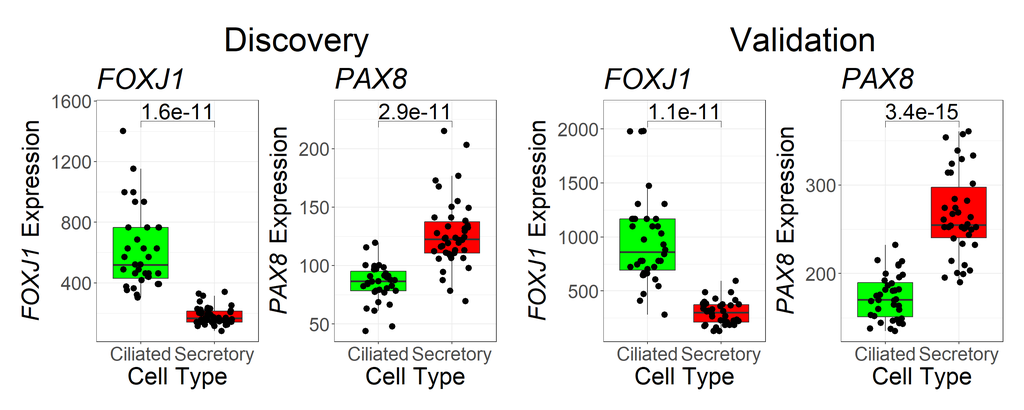

```r
text_size <- 25

# For Discovery Dataset

FOXJ1_d <- cil_v_sec_boxplot_points(gene = "FOXJ1", dataset = disc_q_norm) + theme(text=element_text(size=text_size)) + theme(legend.position = "none")

PAX8_d <- cil_v_sec_boxplot_points(gene = "PAX8", dataset = disc_q_norm) + theme(text=element_text(size=text_size)) + theme(legend.position = "none")


# For Validation Dataset

FOXJ1_v <- cil_v_sec_boxplot_points(gene = "FOXJ1", dataset = valid_q_norm) + theme(text=element_text(size=text_size)) + theme(legend.position = "none")

PAX8_v <- cil_v_sec_boxplot_points(gene = "PAX8", dataset = valid_q_norm) + theme(text=element_text(size=text_size)) + theme(legend.position = "none")



title1 <- grid::textGrob(label = "Discovery", gp=gpar(fontsize=35))
title2 <- grid::textGrob(label = "Validation", gp=gpar(fontsize=35))

# Patchwork is used to combine plots

combine_1 =  (wrap_elements(panel = title1) / (FOXJ1_d + PAX8_d)) + plot_layout(heights = c(1.5, 10))
combine_2 =  (wrap_elements(panel = title2) / (FOXJ1_v + PAX8_v)) + plot_layout(heights = c(1.5, 10))


wrap_elements(combine_1)|wrap_elements(combine_2)
```

# F2. Figure 2

### F2.A-D Secretory Discovery v Validation

The volcano plots used in Figure 2 are generated below.

Some slight differences in genes labeled are expected between different generations.

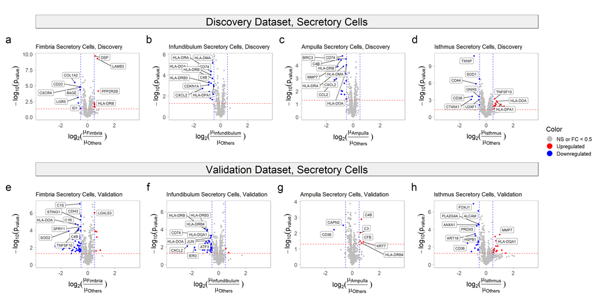

```r
genes_fim_v_other_sec <- get_common_genes(df_1 = one_v_other$disc$sec$fim_v_other, df_2 = one_v_other$valid$sec$fim_v_other, type = "both", FC_cutoff = 0.2)

genes_inf_v_other_sec <- get_common_genes(df_1 = one_v_other$disc$sec$inf_v_other, df_2 = one_v_other$valid$sec$inf_v_other, type = "both", FC_cutoff = 0.2)

genes_amp_v_other_sec <- get_common_genes(df_1 = one_v_other$disc$sec$amp_v_other, df_2 = one_v_other$valid$sec$amp_v_other, type = "both", FC_cutoff = 0.2)

genes_isth_v_other_sec <- get_common_genes(df_1 = one_v_other$disc$sec$isth_v_other, df_2 = one_v_other$valid$sec$isth_v_other, type = "both", FC_cutoff = 0.2)


title = 14

disc_sec <- one_v_other$disc$sec
a <- volcano_plot(df = disc_sec$fim_v_other,
                 title_name = "Fimbria Secretory Cells, Discovery", title_size = title, upreg = "Fimbria", downreg = "Others",
                 #highlight_genes = genes_fim_v_other_sec
                 ) |> add_labels(df = disc_sec$fim_v_other)

b <- volcano_plot(df = disc_sec$inf_v_other,
                 title_name = "Infundibulum Secretory Cells, Discovery", title_size = title, upreg = "Infundibulum", downreg = "Others",
                 #highlight_genes = genes_inf_v_other_sec
                 ) |> add_labels(df = disc_sec$inf_v_other) |> remove_legend()

c <- volcano_plot(df = disc_sec$amp_v_other,
                 title_name = "Ampulla Secretory Cells, Discovery", title_size = title, upreg = "Ampulla", downreg = "Others",
                 #highlight_genes = genes_amp_v_other_sec
                 ) |> add_labels(df = disc_sec$amp_v_other) |> remove_legend()

d <- volcano_plot(df = disc_sec$isth_v_other,
                 title_name = "Isthmus Secretory Cells, Discovery", title_size = title, upreg = "Isthmus", downreg = "Others",
                 #highlight_genes = genes_isth_v_other_sec
                 ) |> add_labels(df = disc_sec$isth_v_other) |> remove_legend()


valid_sec <- one_v_other$valid$sec

w <- volcano_plot(df = valid_sec$fim_v_other,
                 title_name = "Fimbria Secretory Cells, Validation", title_size = title, upreg = "Fimbria", downreg = "Others",
                 #highlight_genes = genes_fim_v_other_sec
                 ) |> add_labels(df = valid_sec$fim_v_other) |> remove_legend()

x <- volcano_plot(df = valid_sec$inf_v_other,
                 title_name = "Infundibulum Secretory Cells, Validation", title_size = title, upreg = "Infundibulum", downreg = "Others",
                 #highlight_genes = genes_inf_v_other_sec
                 ) |> add_labels(df = valid_sec$inf_v_other) |> remove_legend()

y <- volcano_plot(df = valid_sec$amp_v_other,
                 title_name = "Ampulla Secretory Cells, Validation", title_size = title, upreg = "Ampulla", downreg = "Others",
                 #highlight_genes = genes_amp_v_other_sec
                 ) |> add_labels(df = valid_sec$amp_v_other) |> remove_legend()

z <- volcano_plot(df = valid_sec$isth_v_other,
                 title_name = "Isthmus Secretory Cells, Validation", title_size = title, upreg = "Isthmus", downreg = "Others",
                 #highlight_genes = genes_isth_v_other_sec
                 ) |> add_labels(df = valid_sec$isth_v_other) |> remove_legend()

top <-   grobTree(rectGrob(gp=gpar(fill='#F0F0F0',col= 'black')), textGrob('Discovery Dataset, Secretory Cells', gp=gpar(fontsize=25)))

bottom <- grobTree(rectGrob(gp=gpar(fill='#F0F0F0',col= 'black')), textGrob('Validation Dataset, Secretory Cells', gp=gpar(fontsize=25)))

wrap_elements(top) /(a | b | c | d) / wrap_elements(bottom) /(w | x | y | z)  + plot_layout(heights = c(1,5,1,5), guides = "collect") + plot_annotation(tag_levels = list(c("", "a", "b", "c", "d", "", "e", "f", "g", "h"))) &
  theme(plot.tag = element_text(size = 26))
```

### F2.G-J Ciliated Discovery v Validation

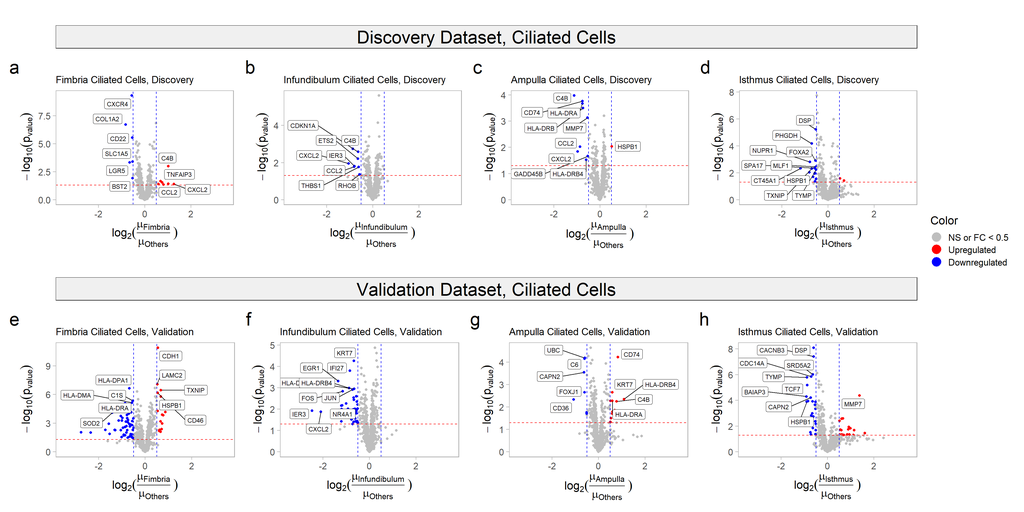

```r
genes_fim_v_other_sec <- get_common_genes(df_1 = one_v_other$disc$cil$fim_v_other, df_2 = one_v_other$valid$cil$fim_v_other, type = "both", FC_cutoff = 0.2)

genes_inf_v_other_sec <- get_common_genes(df_1 = one_v_other$disc$cil$inf_v_other, df_2 = one_v_other$valid$cil$inf_v_other, type = "both", FC_cutoff = 0.2)

genes_amp_v_other_sec <- get_common_genes(df_1 = one_v_other$disc$cil$amp_v_other, df_2 = one_v_other$valid$cil$amp_v_other, type = "both", FC_cutoff = 0.2)

genes_isth_v_other_sec <- get_common_genes(df_1 = one_v_other$disc$cil$isth_v_other, df_2 = one_v_other$valid$cil$isth_v_other, type = "both", FC_cutoff = 0.2)


title = 14

disc_cil <- one_v_other$disc$cil
a <- volcano_plot(df = disc_cil$fim_v_other,
                 title_name = "Fimbria Ciliated Cells, Discovery", title_size = title, upreg = "Fimbria", downreg = "Others",
                 #highlight_genes = genes_fim_v_other_sec
                 ) |> add_labels(df = disc_cil$fim_v_other)

b <- volcano_plot(df = disc_cil$inf_v_other,
                 title_name = "Infundibulum Ciliated Cells, Discovery", title_size = title, upreg = "Infundibulum", downreg = "Others",
                 #highlight_genes = genes_inf_v_other_sec
                 ) |> add_labels(df = disc_cil$inf_v_other) |> remove_legend()

c <- volcano_plot(df = disc_cil$amp_v_other,
                 title_name = "Ampulla Ciliated Cells, Discovery", title_size = title, upreg = "Ampulla", downreg = "Others",
                 #highlight_genes = genes_amp_v_other_sec
                 ) |> add_labels(df = disc_cil$amp_v_other) |> remove_legend()

d <- volcano_plot(df = disc_cil$isth_v_other,
                 title_name = "Isthmus Ciliated Cells, Discovery", title_size = title, upreg = "Isthmus", downreg = "Others",
                 #highlight_genes = genes_isth_v_other_sec
                 ) |> add_labels(df = disc_cil$isth_v_other) |> remove_legend()


valid_cil <- one_v_other$valid$cil

w <- volcano_plot(df = valid_cil$fim_v_other,
                 title_name = "Fimbria Ciliated Cells, Validation", title_size = title, upreg = "Fimbria", downreg = "Others",
                 #highlight_genes = genes_fim_v_other_sec
                 ) |> add_labels(df = valid_cil$fim_v_other) |> remove_legend()

x <- volcano_plot(df = valid_cil$inf_v_other,
                 title_name = "Infundibulum Ciliated Cells, Validation", title_size = title, upreg = "Infundibulum", downreg = "Others",
                 #highlight_genes = genes_inf_v_other_sec
                 ) |> add_labels(df = valid_cil$inf_v_other) |> remove_legend()

y <- volcano_plot(df = valid_cil$amp_v_other,
                 title_name = "Ampulla Ciliated Cells, Validation", title_size = title, upreg = "Ampulla", downreg = "Others",
                 #highlight_genes = genes_amp_v_other_sec
                 ) |> add_labels(df = valid_cil$amp_v_other) |> remove_legend()

z <- volcano_plot(df = valid_cil$isth_v_other,
                 title_name = "Isthmus Ciliated Cells, Validation", title_size = title, upreg = "Isthmus", downreg = "Others",
                 #highlight_genes = genes_isth_v_other_sec
                 ) |> add_labels(df = valid_cil$isth_v_other) |> remove_legend()

top <-   grobTree(rectGrob(gp=gpar(fill='#F0F0F0',col= 'black')), textGrob('Discovery Dataset, Ciliated Cells', gp=gpar(fontsize=25)))

bottom <- grobTree(rectGrob(gp=gpar(fill='#F0F0F0',col= 'black')), textGrob('Validation Dataset, Ciliated Cells', gp=gpar(fontsize=25)))

wrap_elements(top) /(a | b | c | d) / wrap_elements(bottom) /(w | x | y | z)  + plot_layout(heights = c(1,5,1,5), guides = "collect") + plot_annotation(tag_levels = list(c("", "a", "b", "c", "d", "", "e", "f", "g", "h"))) &
  theme(plot.tag = element_text(size = 26))
```

# F3. Figure 3

## F3.1 Figure 3A

Figure 3A is an image generated using BioRender. It is read in below and converted to a ggplot object.

```r
# image_ggplot is from the package "magick"

picture_3A <- image_read(paste0(getwd(), "/pictures/fig3a.jpeg")) |>
  image_ggplot()
```

## F3.2 Figure 3B-C (Volcano plots with mature ciliated cell markers)

#### Markers of Mature Ciliated Cells

The following markers of mature ciliated cells are identified using single cell sequencing by Ulrich et al.

Cellular heterogeneity of human fallopian tubes in normal and hydrosalpinx disease states identified using scRNA-seq

DOI: 10.1016/j.devcel.2022.02.017

```r
mature_cil <- c(
  "CAPS", "CETN2", "PIFO", "C1orf194", "C9orf24", "SNTN", "AGR3", "C20orf85", "MORN2", "PERP", "HMGN3", "TMEM59", "RSPH1",
  "CALM1", "AGR2", "METRN", "DYNLL1", "CD24", "TXN", "PRDX5", "C9orf116", "IK", "MORN5", "FAM183A", "CFAP126", "CAPSL",
  "IGFBP7", "C11orf88", "SPA17", "ODF3B", "CCDC146", "DYNLRB2", "FAM92B", "C9orf135", "PSENEN", "C5orf49", "FAM81B", "ARHGAP18", "PPIL6",
  "SLC44A4", "RBP1", "ANKRD66", "CYSTM1", "MLF1", "CFAP52", "WDR54", "LRRC23", "CTSS", "TAX1BP1", "TPPP3", "GON7", "FAM174A",
  "C6", "TSPAN3", "CIB1", "EFCAB1", "IFT57", "CCDC170", "DYDC2", "ARMC3", "NME5", "ENKUR", "MNS1", "TCTN1", "SMIM22",
  "C11orf97", "WDR78", "MS4A8", "TSPAN6", "FAM216B", "RIIAD1", "FOXJ1", "ARL3", "DRC1", "CTXN1", "ROPN1L", "NUCB2", "EZR",
  "GSTA3", "C4orf48", "MT-ND3", "NELL2", "CCDC113", "SPAG6", "AC013264.1", "GET1", "FXYD3", "TFF3", "EFCAB10", "STK33", "SPATA17",
  "FAIM", "CABCOCO1", "CKB", "TTC29", "KIF21A", "SCGB2A1", "AL357093.2", "STOML3", "CFAP53", "WDR86-AS1", "DNAH9", "C20orf96", "TUBA1A",
  "LDLRAD1", "SAMHD1", "SOD3", "DNAH5", "CCDC173", "ERICH3", "CTSD", "MT-ND5", "TSPAN1", "PLTP", "AK1", "FOLR1", "RHOB",
  "FABP6", "CST6", "PDK4", "ANXA13", "RHOU", "IRX3", "C12orf75", "NEDD9", "MOSPD1", "TMEM190", "CRIP1", "MT-ND4L", "GOLM1",
  "ASRGL1", "SCGB1D4", "GSTA1", "PGR", "G0S2", "FGA", "RRAD"
)
```

### Volc_plot Fimbria v Isthmus Comparisons

```r
title = 20

df1 <- pairwise_comparisons$disc$cil

df2 <- pairwise_comparisons$valid$cil

fim_v_isth_disc <- volcano_plot(df = df1$fim_v_isth,
                 title_name = "Fimbria v Isthmus, Ciliated Cells, Discovery", title_size = title, upreg = "Fimbria", downreg = "Isthmus",
                 highlight_genes = mature_cil
                 ) |> add_labels(df = df1$fim_v_isth, lab_size = 5, highlight_genes = mature_cil, n_genes =0) |> remove_legend()


fim_v_isth_valid <- volcano_plot(df = df2$fim_v_isth,
                 title_name = "Fimbria v Isthmus, Ciliated Cells, Validation",
                 title_size = title, upreg = "Fimbria", downreg = "Isthmus",
                 highlight_genes = mature_cil
                 ) |> add_labels(df = df2$fim_v_isth, lab_size = 5, highlight_genes = mature_cil, n_genes =0) |> remove_legend()



# volcano_plot(df = df2$fim_v_isth,
#                  title_name = "Fimbria v Isthmus, Ciliated Cells, Validation",
#                  title_size = title, upreg = "Fimbria", downreg = "Isthmus",
#                  highlight_genes = mature_cil
#                  )
```

## F3.3 Create Ratio Comparisons

The following functions create ratio comparison plots for figure 3D-E (discovery) and 3J-K (validation).

### FUNCT: make_ratio()

```r
# Ascending Secretory approaching Isthmus



make_ratio <- function(gene1 = "PAX8", gene2 = "FOXJ1", dataset = all_q_norm, title = "All", point_size = 3, selected_segment = NA, make_legend = F){

    dataset_original <- dataset


    # Filter dataset for the selected segment if provided
    if (!is.na(selected_segment)) {
        dataset <- dataset[, pData(dataset)$segment == selected_segment]
    }

    # Compute gene1/gene2 ratio and convert to vector

    vector <- as.vector(assayDataElement(dataset[gene1, ], elt = "q_norm")/
                          assayDataElement(dataset[gene2, ], elt = "q_norm"))

    # Create the ggplot
    plot <- ggplot(
      pData(dataset),
      aes(x = region,
          y = vector,
          fill = region
          )
      )+
      geom_boxplot(outlier.shape = NA) +
      labs(title = TeX(paste0("\\textit{", gene1, "/", gene2, "}")),
           y = TeX(paste0("\\textit{", gene1, "/", gene2, "}")),
           x = "Anatomical Region")+
      facet_wrap(~segment)+

      geom_jitter(size = point_size, width = 0.25, stroke = 1.3, aes(shape = Patient))+

      scale_shape_manual(values = c(3, 4, 13, 21, 22, 23, 24))+

      theme_bw()+

      # scale_x_discrete(labels=c("Fim","Inf","Amp", "Isth"))+
      scale_fill_manual(values= c("#7CAE00", "#00C1C6", "#F8766D", "#C77CFF"))+

      theme(axis.text.x = element_text(size = 15),
            axis.text.y = element_text(size = 12),
            axis.title.y = element_text(size = 15),
            axis.title.x = element_text(size = 15),
            legend.text = element_text(size =12),
            legend.title = element_text(size = 12),
            strip.text = element_text(size = 15))


  # Generate legend and adjust plot sizes
  legend <- make_boxplot_legend(dataset = dataset_original)

  ratio_resize <- adj_text_size(plot, pnt = 17)
  ratio_remove_legend <- remove_legend(ratio_resize)
  ratio_sig <- add_sig(ratio_remove_legend, pnt = 4)

  # Combine the main plot and legend

  if(make_legend){
  plot_final <- (ratio_sig) / legend + plot_layout(heights = c(5, 1))

  return(plot_final)
  }
  plot_final <- ratio_sig

  return(plot_final)

}
```

### Create Ratio Comparisons

```r
# make_ratio(dataset = all_q_norm, title = "All")


# PAX8 / FOXJ1 plots

PvF_disc <- make_ratio(gene1 = "PAX8", gene2 = "FOXJ1", dataset = disc_q_norm, selected_segment = "Secretory")


PvF_valid <- make_ratio(gene1 = "PAX8", gene2 = "FOXJ1", dataset = valid_q_norm, selected_segment = "Secretory")


# FOXJ1/PAX8 plots


FvP_disc <- make_ratio(gene1 = "FOXJ1", gene2 = "PAX8", dataset = disc_q_norm, selected_segment = "Ciliated")


FvP_valid <- make_ratio(gene1 = "FOXJ1", gene2 = "PAX8", dataset = valid_q_norm, selected_segment = "Ciliated")
```

## F3.4 Create Boxplot comparisons

The following sections create the other boxplots for figure 3.

Discovery boxplots Fig3F-I and Validation boxplots Fig3L-O

### FUNCT: make_fig3()

This create boxplots formatted specifically for figure 3

```r
# List of Genes up in Mature Ciliated Cells

Fig3 <- c("MLF1", "SPA17", "CTSS", "C6")


# Function to create boxplots for Figure 3

make_fig3 <- function(genes = Fig3, dataset = all_q_norm, title = "All"){

  graphs_up_Fig3 <- lapply(X = genes, FUN = Cil_v_Sec_Anat_Boxplot_Points, dataset = dataset)



  Fig3_resize <- lapply(graphs_up_Fig3, adj_text_size, pnt = 17)
  Fig3_remove_legend <- lapply(Fig3_resize, remove_legend)
  Fig3_sig <- lapply(Fig3_remove_legend, add_sig, pnt = 4)



  return(Fig3_sig)

  }
```

### Generate Boxplots

```r
F3_disc <- make_fig3(genes = Fig3, dataset = disc_q_norm)

F3_valid <- make_fig3(genes = Fig3, dataset = valid_q_norm)

legend_disc <- make_boxplot_legend(dataset = disc_q_norm)

legend_valid <- make_boxplot_legend(dataset = valid_q_norm)
```

## F3.5 Generate Final Image

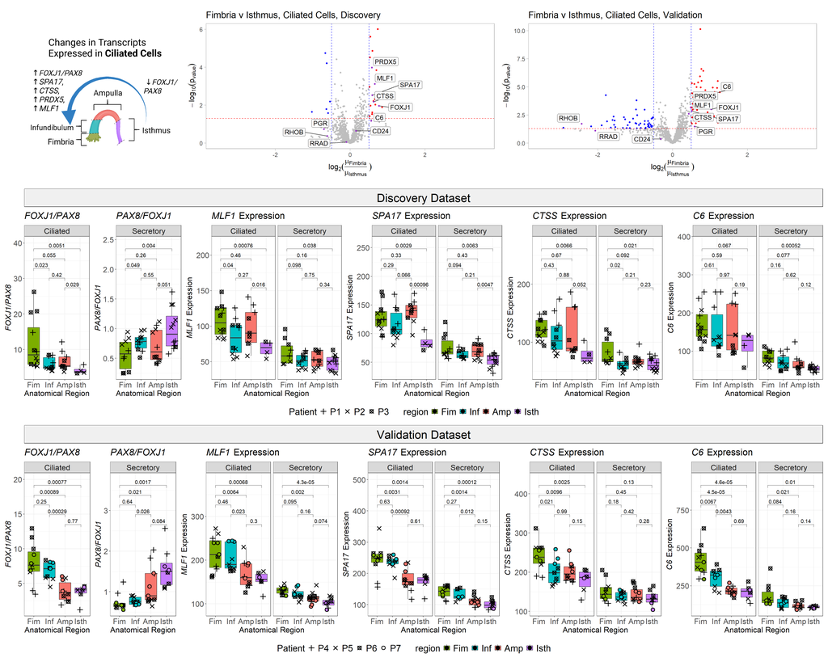

```r
library(patchwork)



# Generate Labels for adding to the graphs

top <- grid::grobTree(rectGrob(gp=gpar(fill='#F0F0F0',col= 'black')), textGrob('Discovery Dataset', gp=gpar(fontsize=25)))

bottom <- grid::grobTree(rectGrob(gp=gpar(fill='#F0F0F0',col= 'black')), textGrob('Validation Dataset', gp=gpar(fontsize=25)))



# Use patchwork to combine the final image into one complete image

wrap_elements(free(picture_3A) | fim_v_isth_disc | fim_v_isth_valid) /
  wrap_elements(top) /

 (((FvP_disc| PvF_disc ) | F3_disc[[1]] | F3_disc[[2]] |  F3_disc[[3]] | F3_disc[[4]]) +
    plot_layout(widths = c(1, 1, 2, 2, 2, 2)))/

 legend_disc /

 wrap_elements(bottom) /

 (((FvP_valid| PvF_valid) | F3_valid[[1]] | F3_valid[[2]] | F3_valid[[3]] |F3_valid[[4]]) +
    plot_layout(widths = c(1, 1, 2, 2, 2, 2)))/

 legend_valid +

 plot_layout(heights = c(5, 0.5, 4, 0.5, 0.5, 4, 0.5))
```